# Psuedo_FB Analyzing single variable

V M KISHORE

1/31/2017

```r
library(ggplot2)
```

load a tab seperated pseudo facebook data

```r
pf <- read.csv('pseudo_facebook.tsv',sep='\t')
str(pf)
```

```
## 'data.frame':    99003 obs. of  15 variables:
##  $ userid               : int  2094382 1192601 2083884 1203168 1733186 1524765 1136133 1680361 1365174 1712567 ...
##  $ age                  : int  14 14 14 14 14 14 13 13 13 13 ...
##  $ dob_day              : int  19 2 16 25 4 1 14 4 1 2 ...
##  $ dob_year             : int  1999 1999 1999 1999 1999 1999 2000 2000 2000 2000 ...
##  $ dob_month            : int  11 11 11 12 12 12 1 1 1 2 ...
##  $ gender               : Factor w/ 2 levels "female","male": 2 1 2 1 2 2 2 1 2 2 ...
##  $ tenure               : int  266 6 13 93 82 15 12 0 81 171 ...
##  $ friend_count         : int  0 0 0 0 0 0 0 0 0 0 ...
##  $ friendships_initiated: int  0 0 0 0 0 0 0 0 0 0 ...
##  $ likes                : int  0 0 0 0 0 0 0 0 0 0 ...
##  $ likes_received       : int  0 0 0 0 0 0 0 0 0 0 ...
##  $ mobile_likes         : int  0 0 0 0 0 0 0 0 0 0 ...
##  $ mobile_likes_received: int  0 0 0 0 0 0 0 0 0 0 ...
##  $ www_likes            : int  0 0 0 0 0 0 0 0 0 0 ...
##  $ www_likes_received   : int  0 0 0 0 0 0 0 0 0 0 ...
```

Scaling

```r
names(pf)
```

```
##  [1] "userid"                "age"
##  [3] "dob_day"               "dob_year"
##  [5] "dob_month"             "gender"
##  [7] "tenure"                "friend_count"
##  [9] "friendships_initiated" "likes"
## [11] "likes_received"        "mobile_likes"
## [13] "mobile_likes_received" "www_likes"
## [15] "www_likes_received"
```

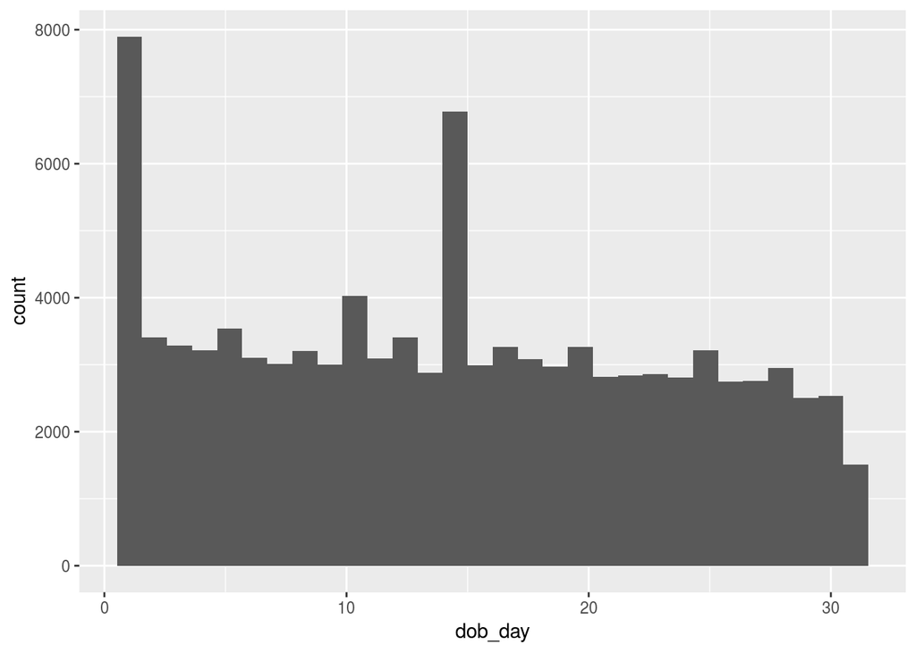

```r
qplot(x=dob_day, data=pf)
```

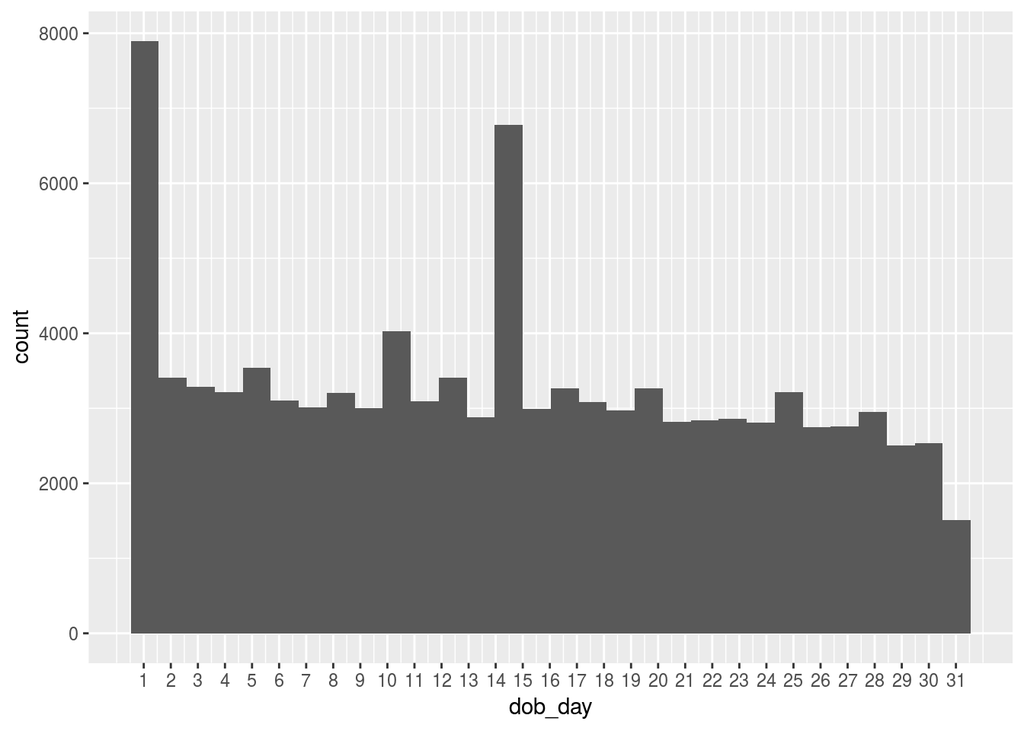

```r
qplot(x=dob_day, data=pf)+
  scale_x_continuous(breaks=1:31)
```

Faceting

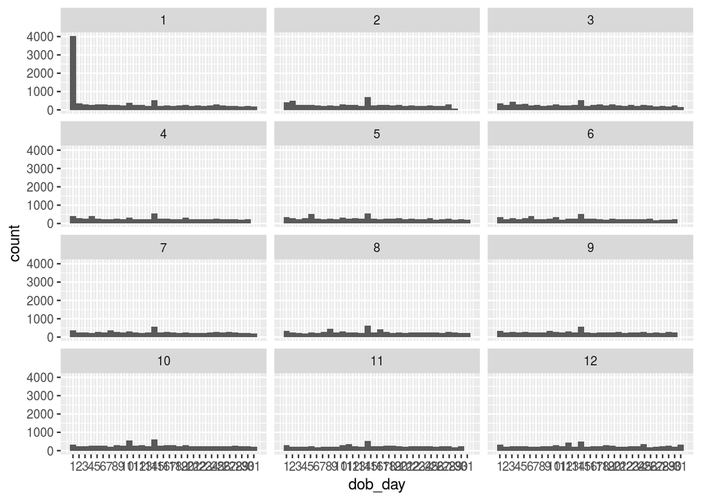

```r
qplot(x=dob_day, data=pf)+
  scale_x_continuous(breaks=1:31)+
facet_wrap(~dob_month,ncol=3)
```

Limiting the X axis. Here I jut limited the x axis data to 500 from zero(ie: friend count less than zero)

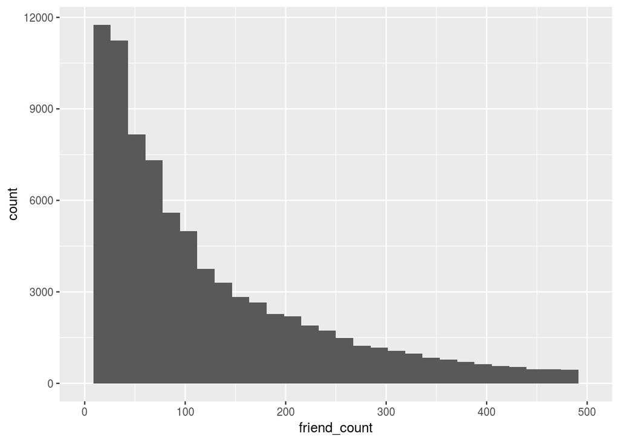

```r
qplot(x=friend_count,data=pf)+
  scale_x_continuous(lim=c(0,500),breaks = seq(0,500,100))
```

Also can written as below

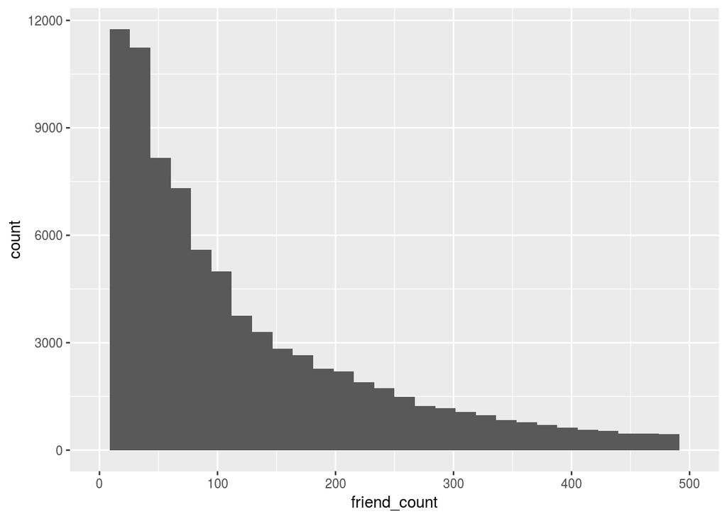

Setting the bin width

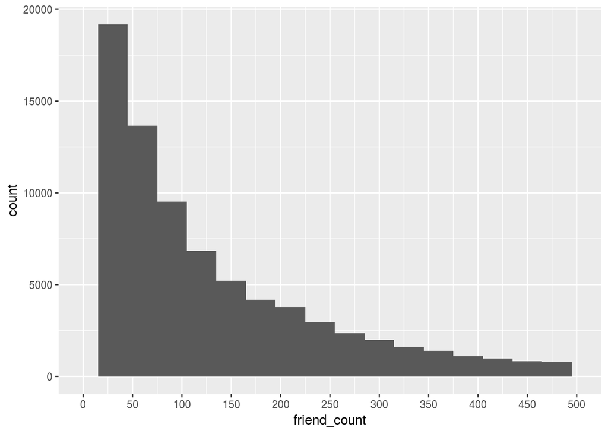

```r
qplot(x=friend_count,data=pf,binwidth=30)+
  scale_x_continuous(limits=c(0,500),breaks = seq(0,500,50))
```

Who has more friends Men or women(Use facter_wrap)

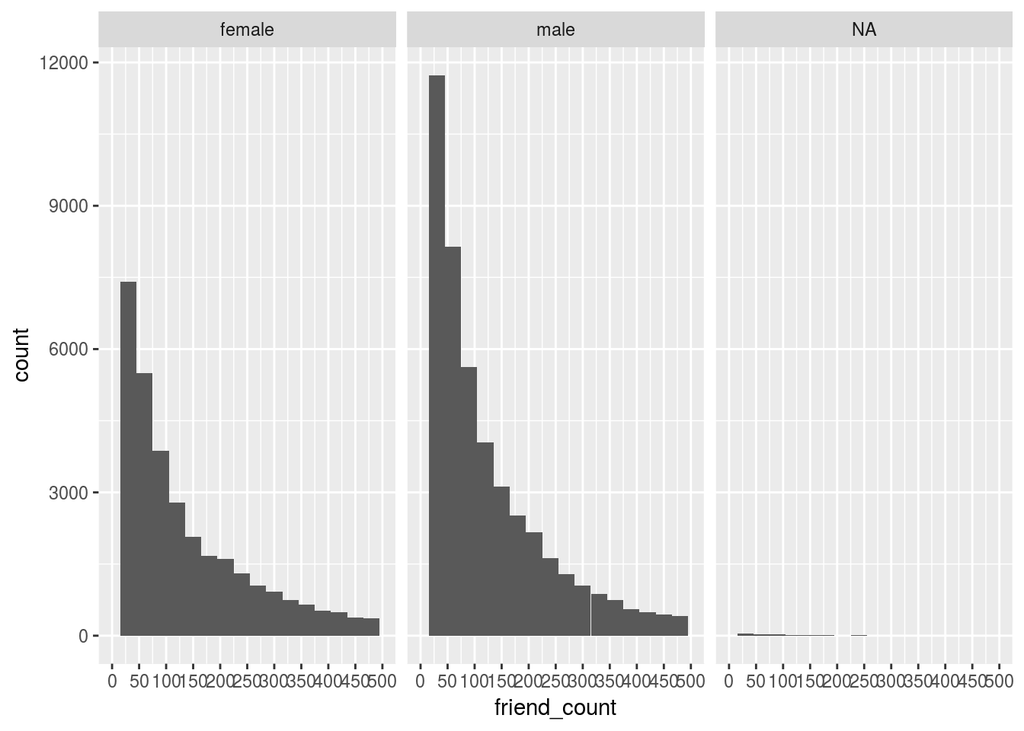

```r
qplot(x=friend_count,data=pf,binwidth=30)+
  scale_x_continuous(limits=c(0,500),breaks = seq(0,500,50))+
                       facet_wrap(~gender)
```

Omitting Na observations

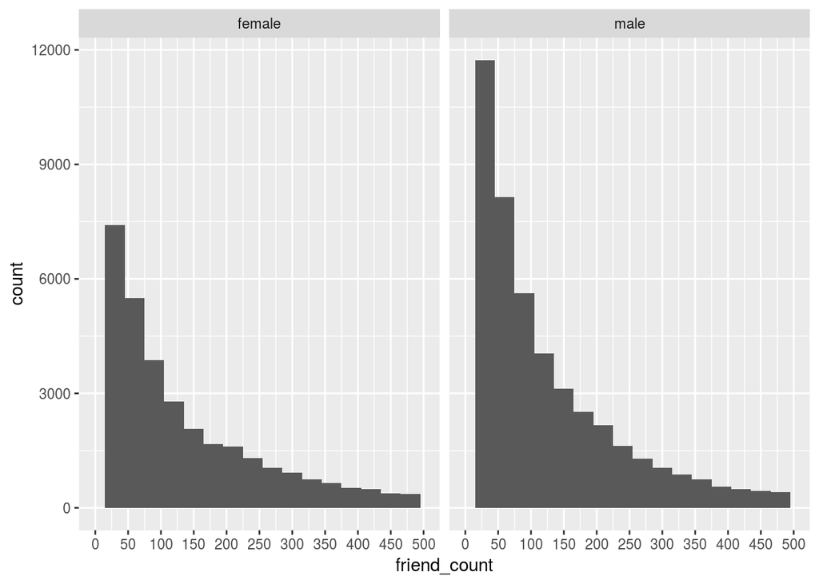

To omit all NA observations

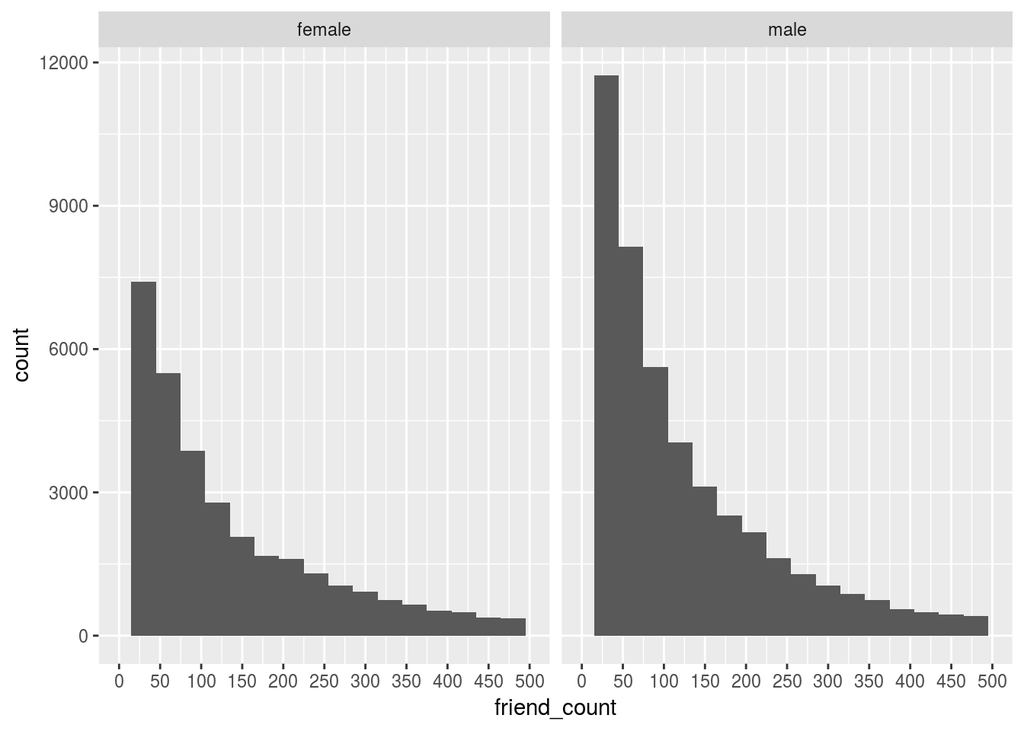

Statistics by gender

```r
table(pf$gender)
```

```
##
## female   male
##  40254  58574
```

```r
by(pf$friend_count,pf$gender,summary)
```

```
## pf$gender: female
##    Min. 1st Qu.  Median    Mean 3rd Qu.    Max.
##       0      37      96     242     244    4923
## --------------------------------------------------------
## pf$gender: male
##    Min. 1st Qu.  Median    Mean 3rd Qu.    Max.
##       0      27      74     165     182    4917
```

Tenure(How many data some one is using facebook)

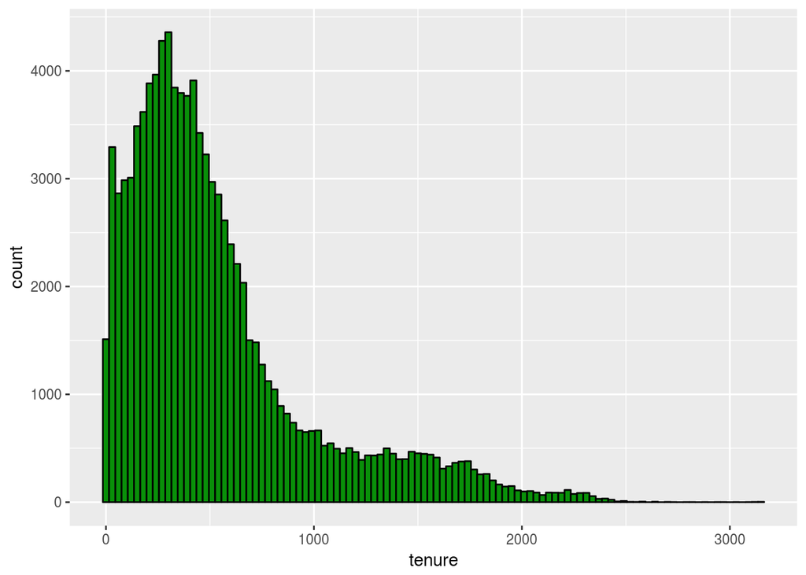

```r
qplot(x=tenure, data=pf, binwidth=30,
      color=I('black'),fill=I('#099009'))
```

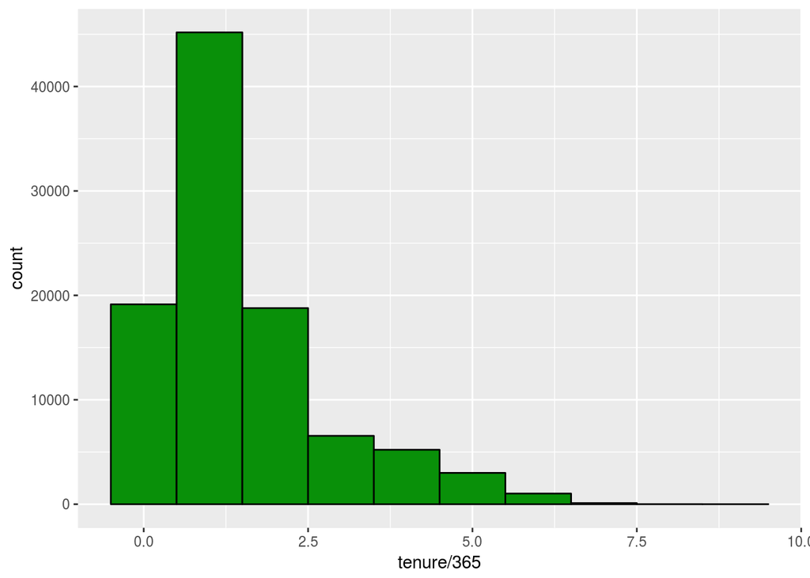

```r
qplot(x=tenure/365,data=pf,binwidth=1,
      color=I('black'),fill=I('#099009'))
```

A yearly view with quarterly bins

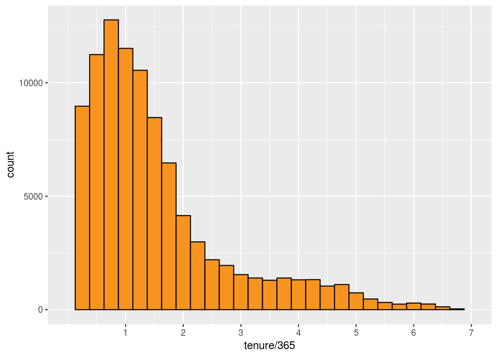

```r
qplot(x=tenure/365,data=pf,binwidth=.25,color=I('black'),fill=I('#F79420'))+
scale_x_continuous(breaks=seq(1,7,1),limit=c(0,7))
```

Labeling plots(By default r tables col names as axis names of the plots)

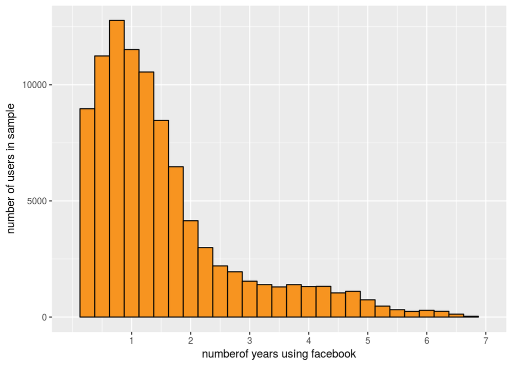

```r
qplot(x=tenure/365,data=pf,binwidth=.25,color=I('black'),fill=I('#F79420'))+
scale_x_continuous(breaks=seq(1,7,1),limit=c(0,7)) +
  xlab('numberof years using facebook')+
  ylab('number of users in sample')
```

User ages facet wrap by gender.

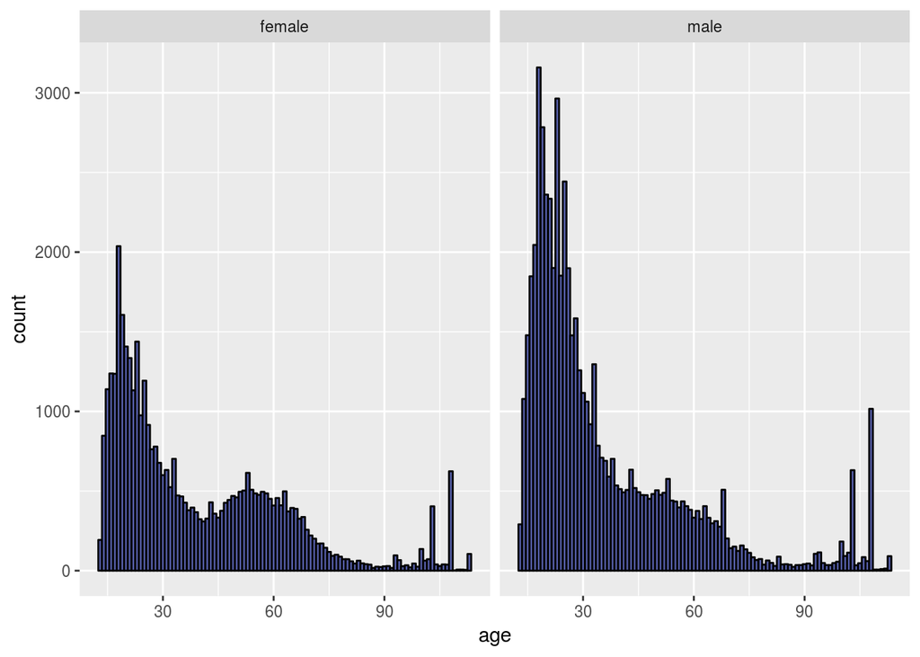

```r
qplot(x=age,data=na.omit(pf),binwidth=1,color=I('black'),fill=I('#5760AB'))+
  facet_wrap(~gender)
```

Transforming data(Over dispersed data can be visualized in a better way)

```r
#install.packages('gridExtra')
library(gridExtra)
summary(log10(pf$friend_count+1))
```

```
##    Min. 1st Qu.  Median    Mean 3rd Qu.    Max.
##   0.000   1.505   1.919   1.868   2.316   3.692
```

```r
summary(log10(pf$friend_count+1))
```

```
##    Min. 1st Qu.  Median    Mean 3rd Qu.    Max.
##   0.000   1.505   1.919   1.868   2.316   3.692
```

```r
summary(sqrt(pf$friend_count+1))
```

```
##    Min. 1st Qu.  Median    Mean 3rd Qu.    Max.
##   1.000   5.657   9.110  11.180  14.390  70.170
```

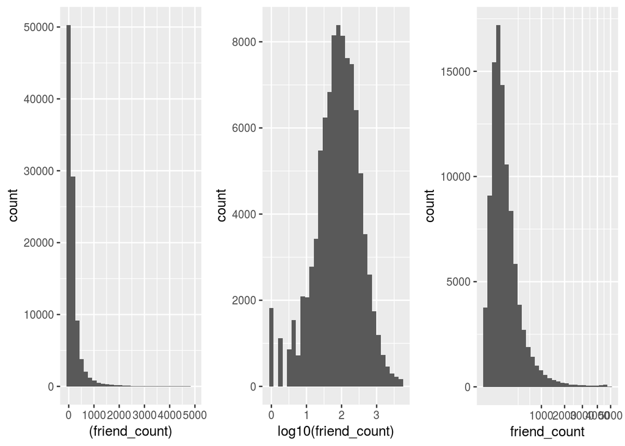

```r
noscale<-qplot(x=(friend_count),data=pf)

logScale<-qplot(x=log10(friend_count),data=pf)

sqrtplot<-ggplot(aes(x=friend_count),data=pf)+geom_histogram()+scale_x_sqrt()

grid.arrange(noscale,logScale,sqrtplot,ncol=3)
```

Transformation data alternate solution

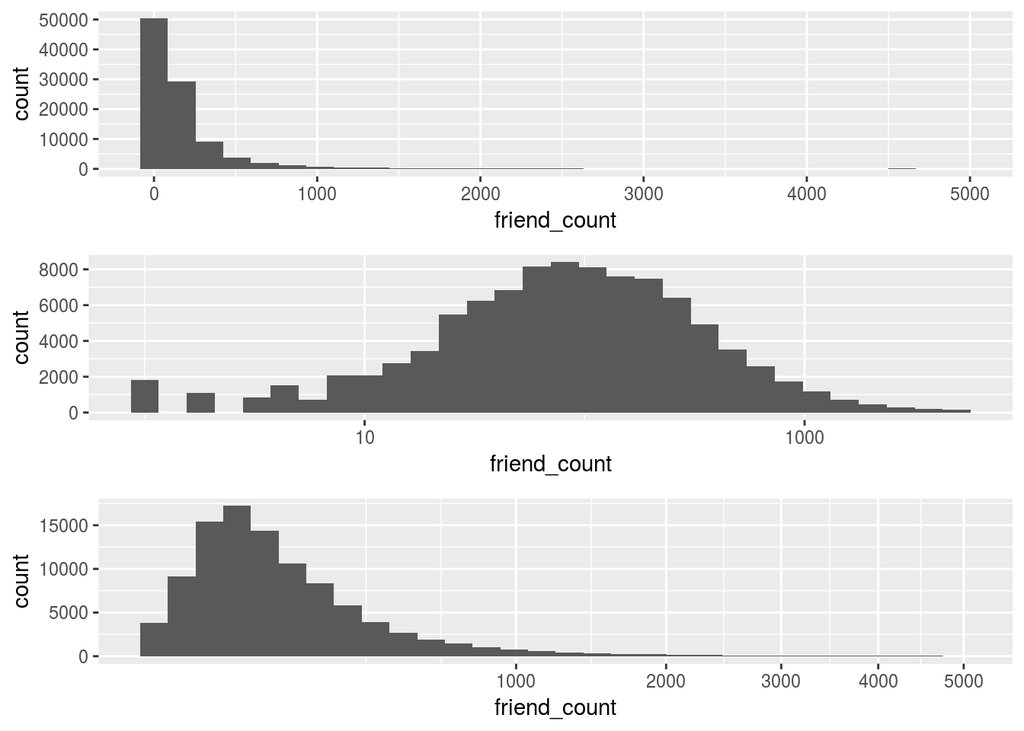

Difference between the transformations wrapper an adding layer

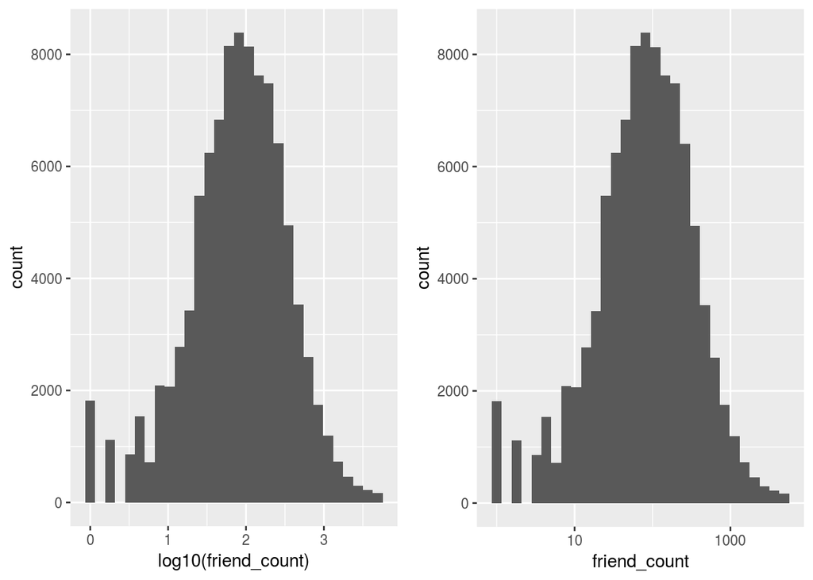

```r
log_wraper<-ggplot(aes(x=log10(friend_count)),data=pf)+geom_histogram()
log_layer<-ggplot(aes(x=friend_count),data=pf)+geom_histogram()+scale_x_log10()
grid.arrange(log_wraper,log_layer,ncol=2)
```

### To compate distrubutiosn Frequency poligons(just before that a histogram)

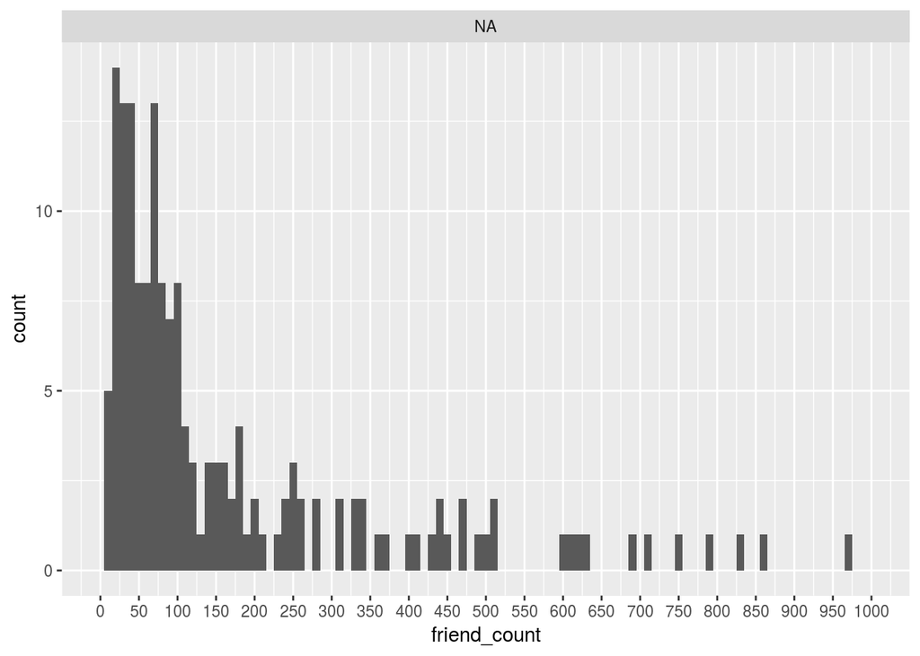

```r
qplot(x= friend_count,data=subset(pf,is.na(gender)),
  binwidth=10)+
scale_x_continuous(lim=c(0,1000),breaks = seq(0, 1000,50)) + facet_wrap(~gender)
```

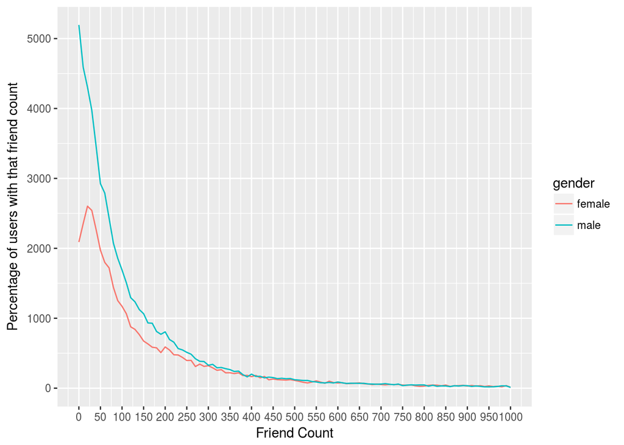

```r
ggplot(aes(x = friend_count), data = subset(pf, !is.na(gender))) +
  geom_freqpoly(aes(color = gender), binwidth=10) +
  scale_x_continuous(limits = c(0, 1000), breaks = seq(0, 1000, 50)) +
  xlab('Friend Count') +
  ylab('Percentage of users with that friend count')
```

But we really wanted to know who have more friends male or female(For this we have to take proportions .The below addition code y = ..count../sum(..count..) will take the proportions )

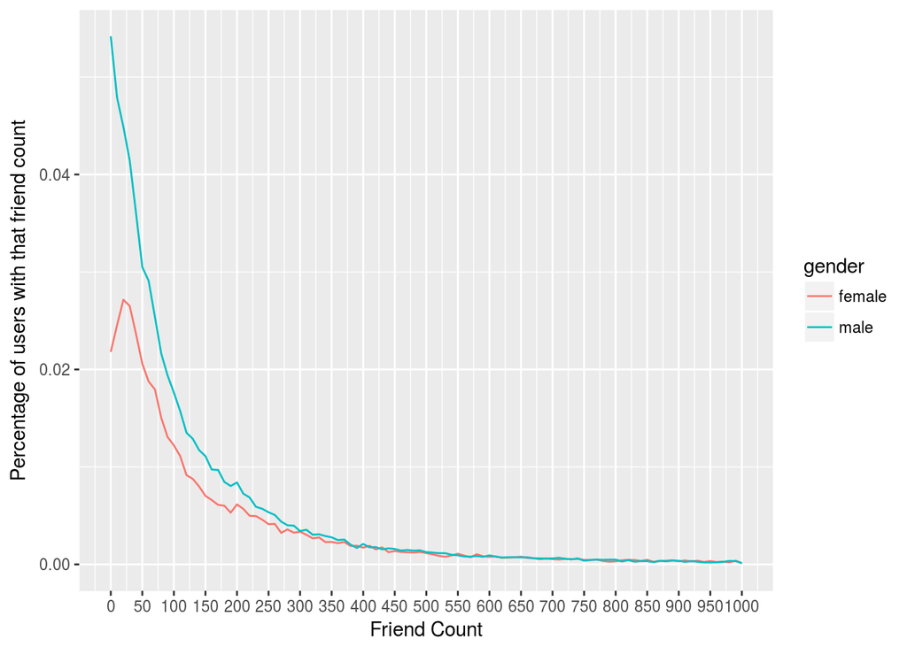

```r
ggplot(aes(x = friend_count, y = ..count../sum(..count..)), data = subset(pf, !is.na(gender))) +
  geom_freqpoly(aes(color = gender), binwidth=10) +
  scale_x_continuous(limits = c(0, 1000), breaks = seq(0, 1000, 50)) +
  xlab('Friend Count') +
  ylab('Percentage of users with that friend count')
```

Frequency polygon for www_likes(The advantage of log transfermation)

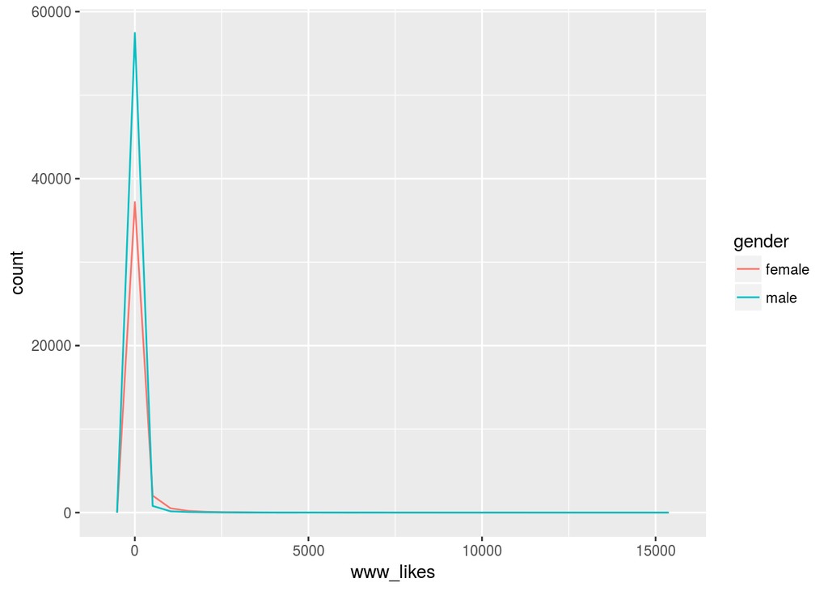

```r
qplot(x=www_likes ,
     data = subset(pf,!is.na(gender)),
     geom='freqpoly',color=gender)+
     scale_x_continuous()
```

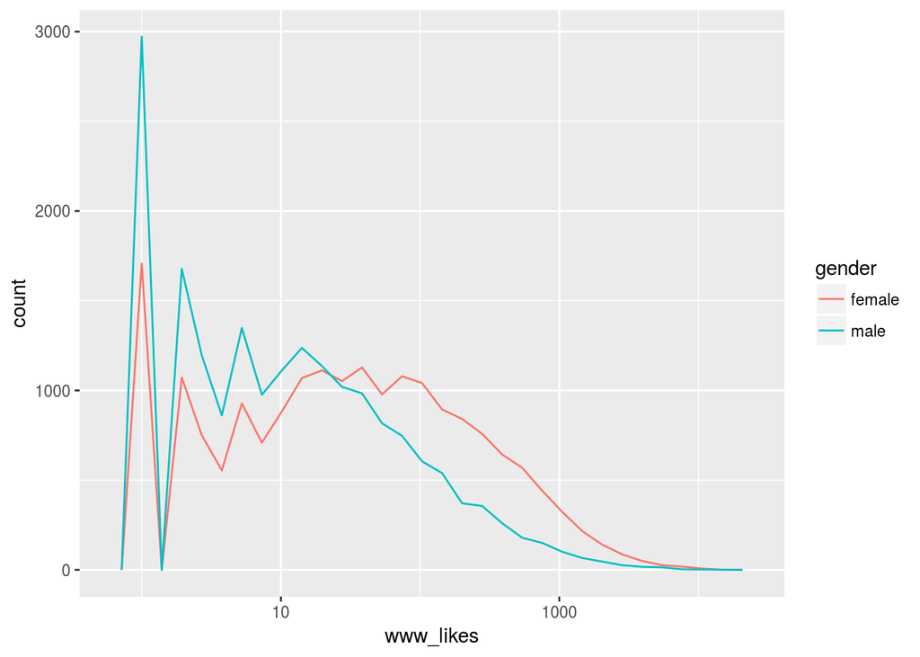

```r
qplot(x=www_likes ,
     data = subset(pf,!is.na(gender)),
     geom='freqpoly',color=gender)+
     scale_x_continuous()+
     scale_x_log10()
```

Summary for www-Likes

```r
by(pf$www_likes,pf$gender,summary)
```

```
## pf$gender: female
##     Min.  1st Qu.   Median     Mean  3rd Qu.     Max.
##     0.00     0.00     0.00    87.14    25.00 14860.00
## --------------------------------------------------------
## pf$gender: male
##     Min.  1st Qu.   Median     Mean  3rd Qu.     Max.
##     0.00     0.00     0.00    24.42     2.00 12900.00
```

```r
by(pf$www_likes,pf$gender,sum)
```

```
## pf$gender: female
## [1] 3507665
## --------------------------------------------------------
## pf$gender: male
## [1] 1430175
```

Box PLots

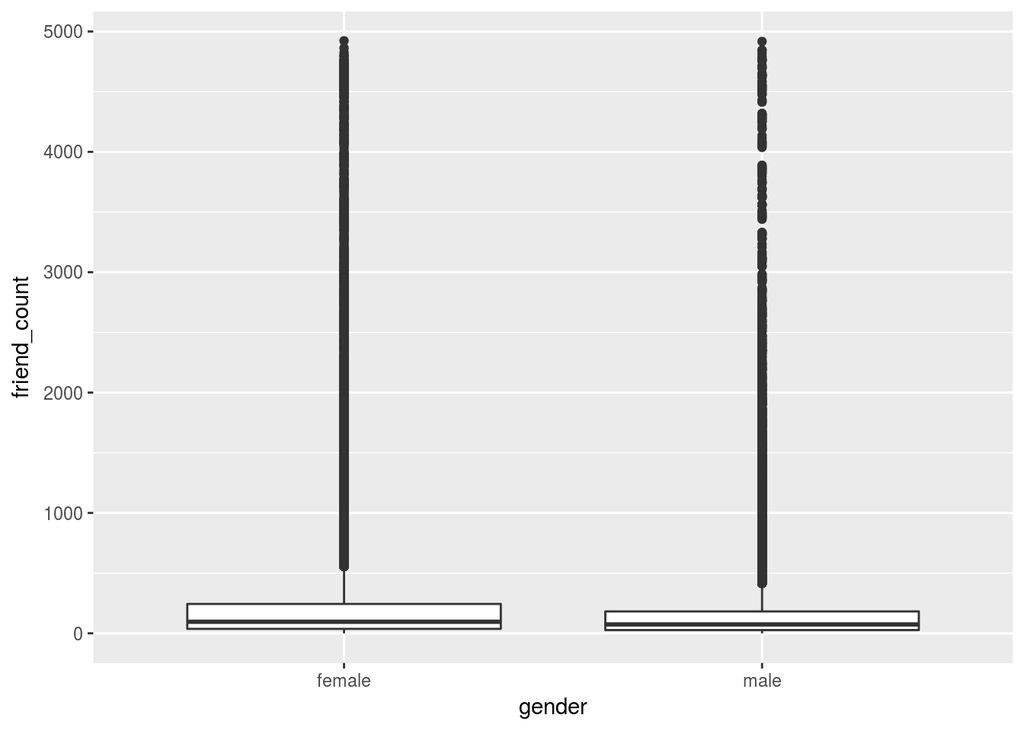

```r
qplot(x=gender, y=friend_count,data=subset(pf, !is.na(gender)),geom='boxplot')
```

Outlier : is just 1.5 times IQR distance from th emedian.set the limits to remove the outliers

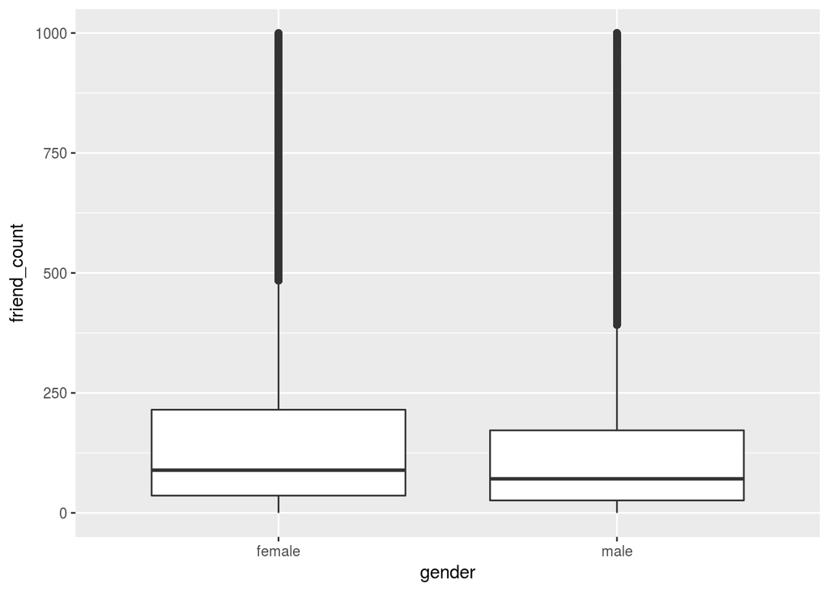

```r
qplot(x=gender, y=friend_count,data=subset(pf, !is.na(gender)),geom='boxplot',ylim=c(0,1000))
```

Set the limits to remove the outliers

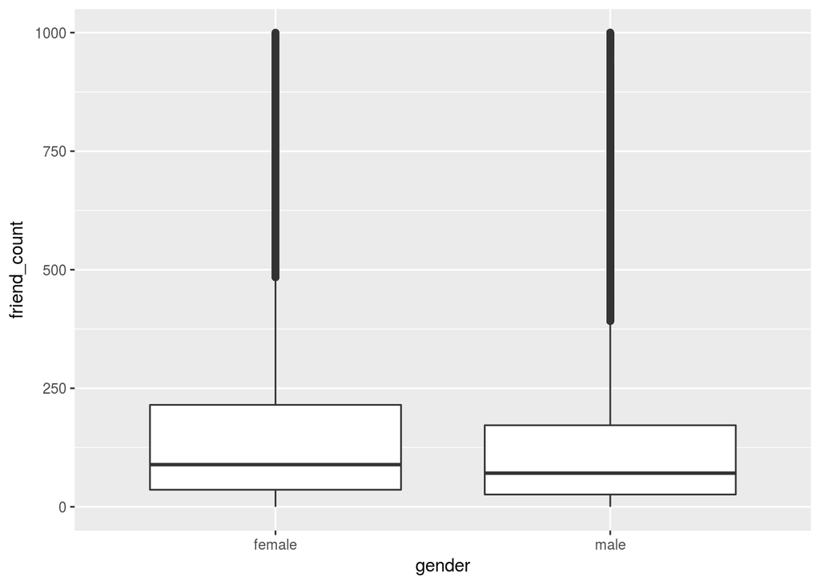

```r
qplot(x=gender, y=friend_count,data=subset(pf, !is.na(gender)),geom='boxplot')+
scale_y_continuous(limits=c(0,1000))
```

to summarize the friend-counts by gender

```r
by(pf$friend_count,pf$gender,summary)
```

```
## pf$gender: female
##    Min. 1st Qu.  Median    Mean 3rd Qu.    Max.
##       0      37      96     242     244    4923
## --------------------------------------------------------
## pf$gender: male
##    Min. 1st Qu.  Median    Mean 3rd Qu.    Max.
##       0      27      74     165     182    4917
```

To match the graph details with the above statistics use the coord_cartesian function. This means , the data point we limit on y-axis is just for visualization not on actual calculation.

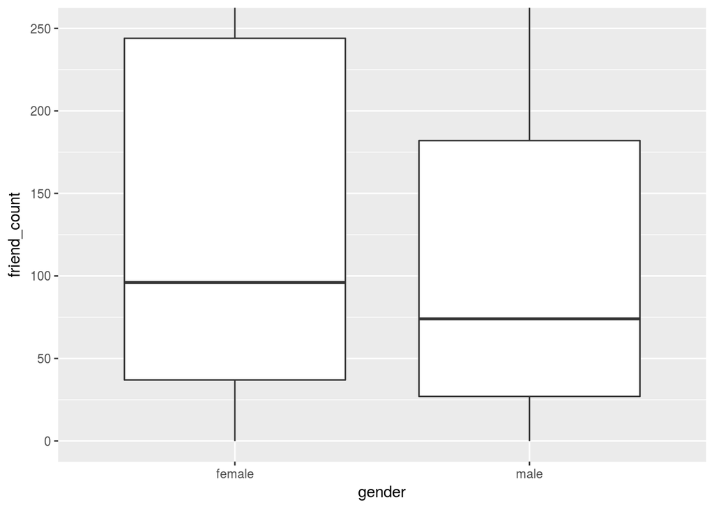

```r
qplot(x=gender, y=friend_count,data=subset(pf,!is.na(gender)),geom='boxplot')+
  coord_cartesian(ylim=c(0,250))
```

On an average who initiated more friend request.(The answer is female)

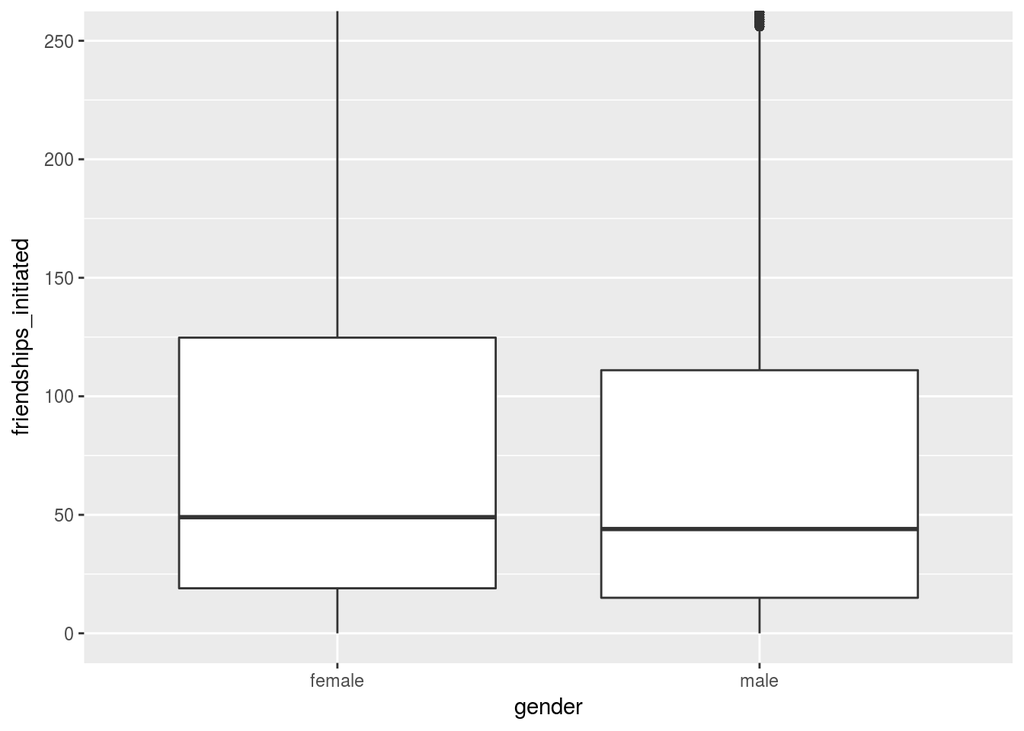

```r
qplot(x=gender, y=friendships_initiated,data=subset(pf,!is.na(gender)),geom='boxplot')+
  coord_cartesian(ylim=c(0,250))
```

```r
by(pf$friendships_initiated,pf$gender,summary)
```

```
## pf$gender: female
##    Min. 1st Qu.  Median    Mean 3rd Qu.    Max.
##     0.0    19.0    49.0   113.9   124.8  3654.0
## --------------------------------------------------------
## pf$gender: male
##    Min. 1st Qu.  Median    Mean 3rd Qu.    Max.
##     0.0    15.0    44.0   103.1   111.0  4144.0
```